# K-Means Clustering for Disaster Risk Analysis

```python
import numpy as np
import pandas as pd
import matplotlib.pyplot as plt
import seaborn as sns
import matplotlib.cm as cm
import geopandas as gpd
import folium
import matplotlib.colors as colors
from folium.plugins import MarkerCluster
from shapely.geometry import Polygon
from mpl_toolkits.mplot3d import Axes3D
from sklearn.cluster import KMeans
from sklearn.metrics import silhouette_score, silhouette_samples
from sklearn.preprocessing import MinMaxScaler
from sklearn.metrics import davies_bouldin_score, calinski_harabasz_score
```

## Introduction

In this project, I will apply K-Means Clustering to analyze and identify areas in Sleman Regency that are most vulnerable to strong wind disasters. This analysis leverages data from two different years to examine vulnerability patterns and changes over time. The primary goal is to use unsupervised machine learning techniques to group regions based on factors such as location, disaster type, and their impacts, providing valuable insights for disaster management and mitigation strategies.

## Data Preprocessing

```python
sleman = pd.read_csv("DATA FIX.csv")
```

These are the elements of the dataset:

```python
sleman.keys()
```

```
Index(['Kecamatan', 'Tahun', 'BanyakKejadian ', 'PohonTumbang ',
       'JaringanListrik '],
      dtype='object')
```

To resolve the issue of unnecessary spaces in the column names of the Sleman dataset, I used the `str.strip()` method to remove extra spaces from the ends of column names like `BanyakKejadian`, `PohonTumbang`, and `JaringanListrik`. This ensures consistency and prevents potential errors when accessing these columns during analysis or visualization.

```python
sleman.columns = sleman.columns.str.strip()
```

With this step, all column names are cleaned and ready for further processing.

The dataset has 34 entries (instances) and 5 columns:

```python
sleman.info()
```

```
<class 'pandas.core.frame.DataFrame'>
RangeIndex: 34 entries, 0 to 33
Data columns (total 5 columns):
 #   Column           Non-Null Count  Dtype
---  ------           --------------  -----
 0   Kecamatan        34 non-null     object
 1   Tahun            34 non-null     int64
 2   BanyakKejadian   34 non-null     int64
 3   PohonTumbang     34 non-null     int64
 4   JaringanListrik  34 non-null     int64
dtypes: int64(4), object(1)
memory usage: 1.5+ KB
```

Check for missing values in dataset

```python
print(sleman.isnull().any())
```

```
Kecamatan          False
Tahun              False
BanyakKejadian     False
PohonTumbang       False
JaringanListrik    False
dtype: bool
```

All columns have no missing values.

View the statistical summary of numerical variables

```python
sleman.describe()
```

|  | Tahun | BanyakKejadian | PohonTumbang | JaringanListrik |
| --- | --- | --- | --- | --- |
| count | 34.000000 | 34.000000 | 34.000000 | 34.000000 |
| mean | 2020.500000 | 55.176471 | 26.352941 | 5.764706 |
| std | 0.507519 | 39.009300 | 33.562138 | 4.742195 |
| min | 2020.000000 | 0.000000 | 0.000000 | 0.000000 |
| 25% | 2020.000000 | 27.000000 | 2.000000 | 2.000000 |
| 50% | 2020.500000 | 49.000000 | 7.000000 | 4.000000 |
| 75% | 2021.000000 | 76.000000 | 44.000000 | 9.500000 |
| max | 2021.000000 | 158.000000 | 130.000000 | 20.000000 |

## Exploratory Data Analysis

### Feature Scaling

To balance clustering results, key features `BanyakKejadian`, `PohonTumbang`, and `JaringanListrik` are standardized using MinMaxScaler. This transformation scales all values between 0 and 1, preventing any feature from disproportionately influencing clustering results.

```python
scaler = MinMaxScaler()
sleman[['BanyakKejadian', 'PohonTumbang', 'JaringanListrik']] = scaler.fit_transform(
    sleman[['BanyakKejadian', 'PohonTumbang', 'JaringanListrik']])
```

### Determining the Optimal Number of Clusters

Two methods are used to determine the optimal number of clusters (k):

- **Elbow Method:** Plots the Within-Cluster Sum of Squares (WSS) for different k values. The elbow point in the graph suggests the ideal cluster count.
- **Silhouette Analysis:** Evaluates how well each data point fits within its assigned cluster by computing the Silhouette Score. A higher score indicates well-defined clusters.

Below is the Python implementation:

#### Elbow Method

```python
# Function to calculate WSS for Elbow Method
def calculate_WSS(X, max_clusters=15):
    """Computes Within-Cluster Sum of Squares (WSS) for different cluster counts"""
    wss = []
    for i in range(1, max_clusters + 1):
        kmeans = KMeans(n_clusters=i, random_state=42, n_init=10)
        kmeans.fit(X)
        wss.append(kmeans.inertia_)
    return wss
```

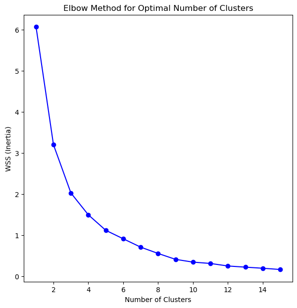

```python
# Compute WCCS
wss = calculate_WSS(sleman[['BanyakKejadian', 'PohonTumbang', 'JaringanListrik']])

# Plot the Elbow Method graph
plt.figure(figsize=[7, 7])
plt.plot(range(1, 16), wss, "b-o")
plt.title("Elbow Method for Optimal Number of Clusters")
plt.xlabel("Number of Clusters")
plt.ylabel("WSS (Inertia)")
plt.show()
```

The optimal number of clusters is determined by the elbow point in the graph. From the plot, it is observed that the elbow occurs at 3 clusters. To further validate this selection, we conduct a Silhouette Analysis.

#### Silhouette Analysis

```python
# Function to perform Silhouette Analysis
def silhouette_analysis(X):
    """Performs Silhouette Analysis for different cluster counts"""
    range_n_clusters = [2, 3, 4, 5]
    for n_clusters in range_n_clusters:
        # Create figure for visualization
        fig, (ax1, ax2) = plt.subplots(1, 2, figsize=(18, 7))

        # Set limits for silhouette plot
        ax1.set_xlim([-0.1, 1])
        ax1.set_ylim([0, len(X) + (n_clusters + 1) * 10])

        # Perform clustering
        clusterer = KMeans(n_clusters=n_clusters, random_state=10, n_init=10)
        cluster_labels = clusterer.fit_predict(X)

        # Compute Silhouette Score
        silhouette_avg = silhouette_score(X, cluster_labels)
        print(f"For n_clusters = {n_clusters}, the average silhouette_score is: {silhouette_avg}")

        # Compute silhouette samples
        sample_silhouette_values = silhouette_samples(X.to_numpy(), cluster_labels)
        y_lower = 10

        for i in range(n_clusters):
            # Collect silhouette scores for each cluster
            ith_cluster_silhouette_values = sample_silhouette_values[cluster_labels == i]
            ith_cluster_silhouette_values.sort()

            size_cluster_i = ith_cluster_silhouette_values.shape[0]
            y_upper = y_lower + size_cluster_i
            color = cm.nipy_spectral(float(i) / n_clusters)

            # Fill silhouette plot
            ax1.fill_betweenx(np.arange(y_lower, y_upper), 0, ith_cluster_silhouette_values, facecolor=color, edgecolor=color, alpha=0.7)

            ax1.text(-0.05, y_lower + 0.5 * size_cluster_i, str(i))
            y_lower = y_upper + 10 # Adjust y-axis for next cluster

        # Set silhouette plot labels
        ax1.set_title(f"Silhouette plot for n_clusters = {n_clusters}")
        ax1.set_xlabel("Silhouette Coefficient")
        ax1.set_ylabel("Cluster label")
        ax1.axvline(x=silhouette_avg, color="red", linestyle="--")
        ax1.set_yticks([])

        # Scatter plot of clusters
        colors = cm.nipy_spectral(cluster_labels.astype(float) / n_clusters)
        ax2.scatter(X.iloc[:, 0], X.iloc[:, 1], marker=".", s=300, lw=0, alpha=0.7, c=colors, edgecolor="k")
        centers = clusterer.cluster_centers_
        ax2.scatter(centers[:, 0], centers[:, 1], marker="o", c="white", alpha=1, s=200, edgecolor="k")

        # Plot cluster centers
        for i, c in enumerate(centers):
            ax2.scatter(c[0], c[1], marker="$%d$" % i, alpha=1, s=50, edgecolor="k")

        # Set cluster visualization labels
        ax2.set_title("Visualization of the Clusters")
        ax2.set_xlabel("Feature 1")
        ax2.set_ylabel("Feature 2")

        plt.suptitle(f"Silhouette analysis for KMeans clustering on n_clusters = {n_clusters}", fontsize=14, fontweight="bold")
        plt.show()
```

```
For n_clusters = 2, the average silhouette_score is: 0.4348766823459905
```

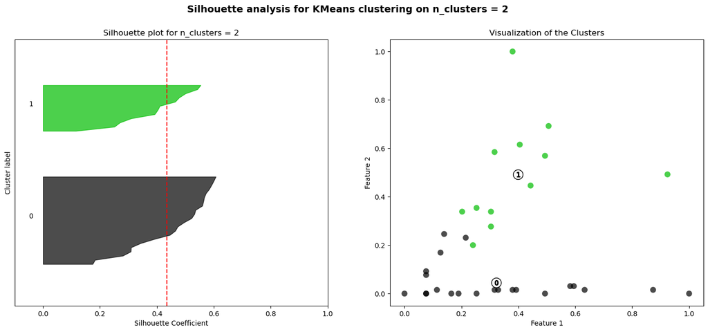

```
For n_clusters = 3, the average silhouette_score is: 0.4399562742024012
```

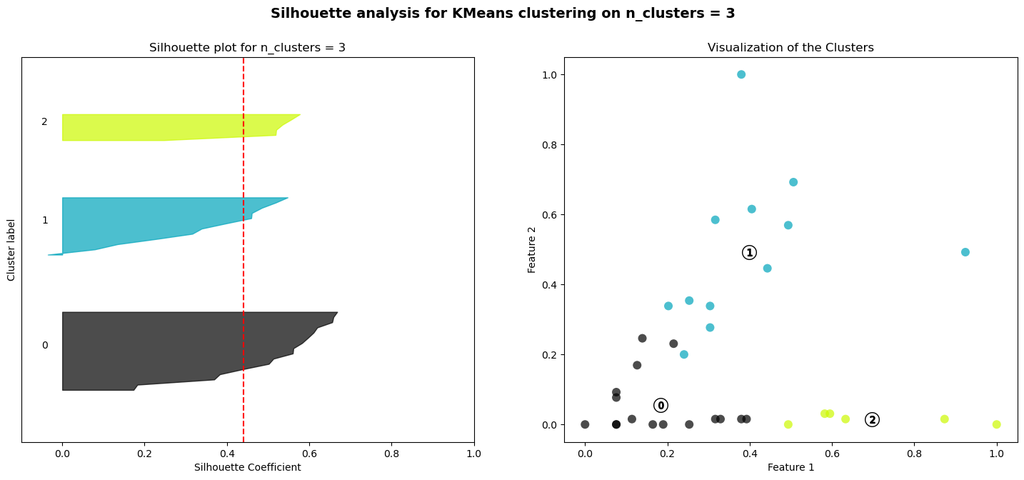

```
For n_clusters = 4, the average silhouette_score is: 0.38198458408835756
```

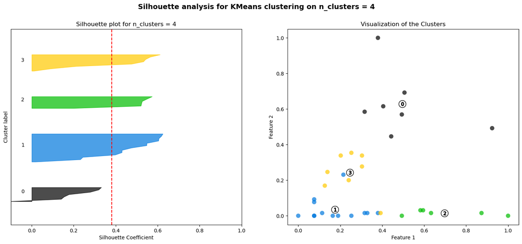

```
For n_clusters = 5, the average silhouette_score is: 0.3893482722402395
```

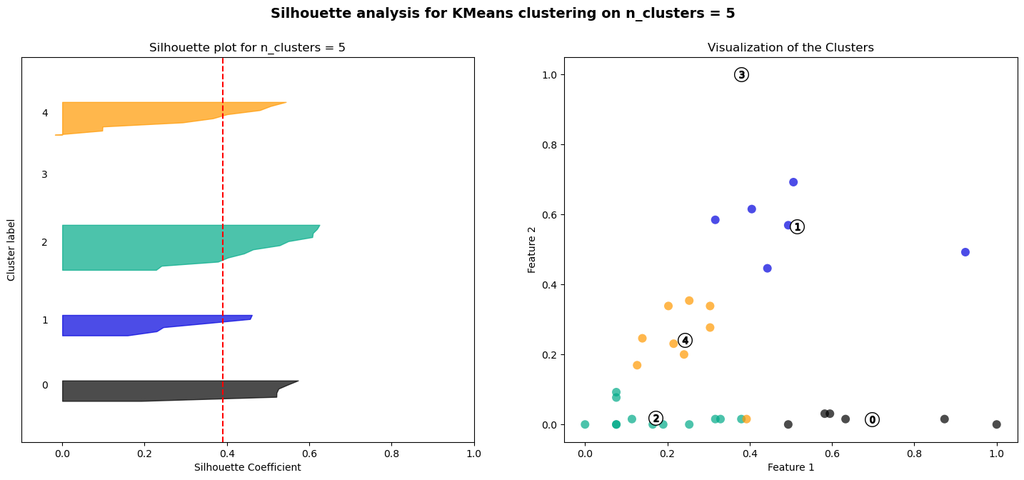

```python
# Perform Silhouette Analysis
silhouette_analysis(sleman[['BanyakKejadian', 'PohonTumbang', 'JaringanListrik']])
```

The Silhouette Score determines the best number of clusters based on how well-separated they are. The highest Silhouette Score observed is 0.4399562742024012, which corresponds to 3 clusters. Therefore, based on these methods, the optimal number of clusters is determined to be 3.

## K-Means Clustering

```python
kmeans = KMeans(n_clusters=3, random_state=123, n_init=10)
kmeans.fit(sleman[['BanyakKejadian', 'PohonTumbang', 'JaringanListrik']])
```

```
KMeans(n_clusters=3, n_init=10, random_state=123)
```

#### Assign Label Cluster

```python
# Displaying centroid values to determine the highest risk
centers = kmeans.cluster_centers_
centroid_df = pd.DataFrame(centers, columns=['BanyakKejadian', 'PohonTumbang', 'JaringanListrik'])
centroid_df['Cluster'] = [0, 1, 2]

# Sorting clusters based on risk level
centroid_df = centroid_df.sort_values(by=['BanyakKejadian', 'PohonTumbang', 'JaringanListrik'], ascending=False)
centroid_mapping = {old: new for new, old in enumerate(centroid_df['Cluster'])}
sleman['Cluster'] = kmeans.labels_
# After assigning the labels based on centroid mapping
sleman['Cluster'] = sleman['Cluster'].map(centroid_mapping)
```

#### Scatter Plot Clustering

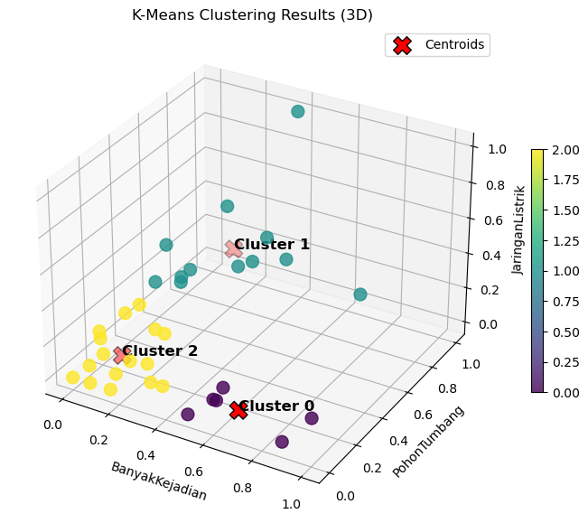

```python
# 3D Scatter Plot
fig = plt.figure(figsize=(10, 7))
ax = fig.add_subplot(111, projection='3d')

# Scatter Plot with a clearer color map
scatter = ax.scatter(
    sleman['BanyakKejadian'],
    sleman['PohonTumbang'],
    sleman['JaringanListrik'],
    c=sleman['Cluster'],
    cmap='viridis',  # More intuitive color scheme
    s=100,
    alpha=0.8
)

# Plot centroids with labels
ax.scatter(
    centers[:, 0],
    centers[:, 1],
    centers[:, 2],
    c='red',
    s=200,
    marker='X',
    edgecolor='k',
    label='Centroids'
)

# Add labels to centroids
for i, (x, y, z) in enumerate(centers):
    ax.text(x, y, z, f'Cluster {i}', color='black', fontsize=12, weight='bold')

# Labels and Titles
ax.set_title("K-Means Clustering Results (3D)")
ax.set_xlabel("BanyakKejadian")
ax.set_ylabel("PohonTumbang")
ax.set_zlabel("JaringanListrik")

plt.legend()
plt.colorbar(scatter, ax=ax, shrink=0.5)
plt.show()
```

#### Cluster Characteristics

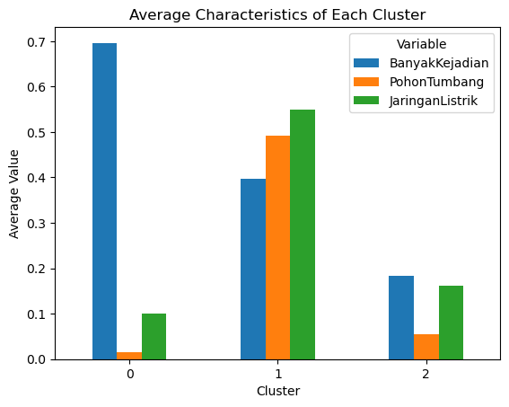

```python
# Profile of each cluster
profil = sleman.groupby("Cluster").mean(numeric_only=True)
profil["cluster"] = profil.index

# Cluster profile plot
profil.plot(x="cluster", y=["BanyakKejadian", "PohonTumbang", "JaringanListrik"], kind="bar")

# Display settings
plt.xticks(rotation=0)
plt.xlabel("Cluster")
plt.ylabel("Average Value")
plt.title("Average Characteristics of Each Cluster")
plt.legend(title="Variable")
plt.show()
```

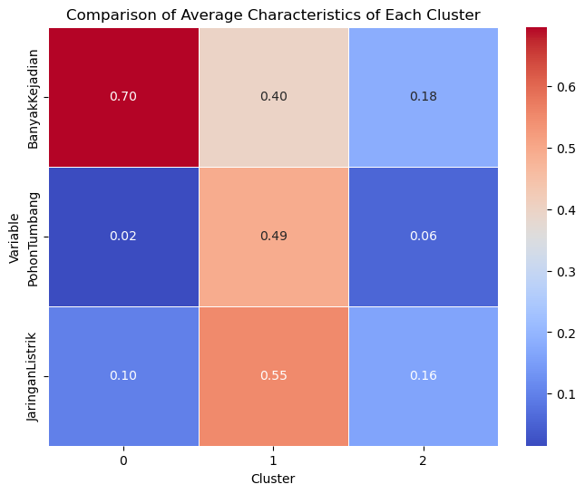

```python
# Plot the Heatmaps
plt.figure(figsize=(8,6))
sns.heatmap(profil.drop(columns=["cluster", "Tahun"]).T, cmap="coolwarm", annot=True, fmt=".2f", linewidths=0.5)
plt.title("Comparison of Average Characteristics of Each Cluster")
plt.xlabel("Cluster")
plt.ylabel("Variable")
plt.show()
```

#### Cluster Distribution

```python
print(sleman["Cluster"].value_counts())
```

```
Cluster
2    16
1    12
0     6
Name: count, dtype: int64
```

#### Cluster Members Overview

```python
for tahun in sorted(sleman["Tahun"].unique()):  # Loop for each year
    print(f"\n=== Tahun {tahun} ===")

    for i in range(sleman["Cluster"].nunique()):  # Loop for each cluster
        cluster_data = sleman[(sleman["Cluster"] == i) & (sleman["Tahun"] == tahun)]

        if not cluster_data.empty:
            print(f"\n🔹 Member Cluster {i}:")
            print(cluster_data)
        else:
            print(f"\n⚠️ There is no data for Cluster {i} in Year {tahun}")
```

```
=== Tahun 2020 ===

⚠️ There is no data for Cluster 0 in Year 2020

🔹 Member Cluster 1:
      Kecamatan  Tahun  BanyakKejadian  PohonTumbang  JaringanListrik  Cluster
2   Cangkringan   2020        0.379747      1.000000              1.0        1
4         Depok   2020        0.240506      0.200000              0.5        1
6       Gamping   2020        0.506329      0.692308              0.4        1
10      Kalasan   2020        0.924051      0.492308              0.5        1
12      Minggir   2020        0.253165      0.353846              0.4        1
14        Mlati   2020        0.443038      0.446154              0.5        1
16      Moyudan   2020        0.405063      0.615385              0.4        1
18      Ngaglik   2020        0.316456      0.584615              0.7        1
20     Ngemplak   2020        0.493671      0.569231              0.6        1
22        Pakem   2020        0.303797      0.276923              0.5        1
24    Prambanan   2020        0.202532      0.338462              0.6        1
28       Sleman   2020        0.303797      0.338462              0.5        1

🔹 Member Cluster 2:
   Kecamatan  Tahun  BanyakKejadian  PohonTumbang  JaringanListrik  Cluster
0     Berbah   2020        0.215190      0.230769              0.2        2
8     Godean   2020        0.126582      0.169231              0.3        2
26   Seyegan   2020        0.075949      0.076923              0.2        2
30    Tempel   2020        0.139241      0.246154              0.3        2
32      Turi   2020        0.075949      0.092308              0.1        2

=== Tahun 2021 ===

🔹 Member Cluster 0:
      Kecamatan  Tahun  BanyakKejadian  PohonTumbang  JaringanListrik  Cluster
3   Cangkringan   2021        0.493671      0.000000              0.0        0
5         Depok   2021        1.000000      0.000000              0.2        0
21     Ngemplak   2021        0.582278      0.030769              0.1        0
23        Pakem   2021        0.594937      0.030769              0.1        0
31       Tempel   2021        0.632911      0.015385              0.2        0
33         Turi   2021        0.873418      0.015385              0.0        0

⚠️ There is no data for Cluster 1 in Year 2021

🔹 Member Cluster 2:
    Kecamatan  Tahun  BanyakKejadian  PohonTumbang  JaringanListrik  Cluster
1      Berbah   2021        0.113924      0.015385              0.3        2
7     Gamping   2021        0.329114      0.015385              0.1        2
9      Godean   2021        0.075949      0.000000              0.1        2
11    Kalasan   2021        0.189873      0.000000              0.1        2
13    Minggir   2021        0.164557      0.000000              0.0        2
15      Mlati   2021        0.253165      0.000000              0.2        2
17    Moyudan   2021        0.000000      0.000000              0.0        2
19    Ngaglik   2021        0.316456      0.015385              0.2        2
25  Prambanan   2021        0.379747      0.015385              0.1        2
27    Seyegan   2021        0.075949      0.000000              0.0        2
29     Sleman   2021        0.392405      0.015385              0.4        2
```

#### Evaluation Metrics

To assess the quality of clustering, we utilize the Davies-Bouldin Index (DBI) and Calinski-Harabasz Index (CHI).

```python
# Calculating the Davies-Bouldin Index
db_index = davies_bouldin_score(sleman[['BanyakKejadian', 'PohonTumbang', 'JaringanListrik']], sleman['Cluster'])
print(f'Davies-Bouldin Index: {db_index}')
```

```
Davies-Bouldin Index: 0.7145964150926428
```

```python
# Calculating the Calinski-Harabasz Index
ch_index = calinski_harabasz_score(sleman[['BanyakKejadian', 'PohonTumbang', 'JaringanListrik']], sleman['Cluster'])
print(f'Calinski-Harabasz Index: {ch_index}')
```

```
Calinski-Harabasz Index: 30.9975256678545
```

The Davies-Bouldin Index (DBI) is 0.71, indicating well-separated and compact clusters. Although this score suggests fairly good clustering results with minimal overlap, there is still room for improvement in cluster compactness. On the other hand, the Calinski-Harabasz Index (CHI) is 30.99, showing that the clusters are well-defined and distinctly separated. This suggests that the applied clustering model has successfully grouped the data with a clear structure.

### Geospatial Clustering Visualization

#### Load the Data

The analysis started by loading a dataset `df` containing information about the districts in Sleman, along with a shapefile `kecamatan` containing the geographical boundaries of each district.

```python
# Load Data Clustering
df = sleman

# Load Shapefile Kecamatan
kecamatan = gpd.read_file("shp sleman.shp")
```

Check the Columns in the Shapefile

```python
print(kecamatan.columns)
```

```
Index(['PROVINSI', 'KECAMATAN', 'KODE_KEC', 'KODE_KAB', 'SHAPE_LENG',
       'KODE_PROP', 'KABUPATEN', 'SHAPE_LE_1', 'SHAPE_AREA', 'geometry'],
      dtype='object')
```

The clustering data `df` is merged with the shapefile `kecamatan` based on the common Kecamatan column.

To ensure compatibility between the data and the shapefile, the Coordinate Reference System (CRS) of the shapefile was transformed to EPSG:4326.

```python
print("CRS before:", kecamatan.crs)
kecamatan = kecamatan.to_crs(epsg=4326)
print("CRS after:", kecamatan.crs)
```

```
CRS before: EPSG:32749
CRS after: EPSG:4326
```

```python
df_gdf = df.merge(kecamatan[['KECAMATAN', 'geometry']],
                  left_on='Kecamatan', right_on='KECAMATAN', how='left')
```

After merging the clustering data with the shapefile, the dataset `df_gdf` is converted into a `GeoDataFrame`.

```python
df_gdf = gpd.GeoDataFrame(df_gdf, geometry='geometry', crs="EPSG:4326")
```

Handle Missing or Invalid Geometry

```python
# Fill empty geometry with an empty Polygon
df_gdf["geometry"] = df_gdf["geometry"].apply(lambda geom: Polygon() if geom is None else geom)

# Convert 3D Polygon (with Z values) to 2D Polygon if it has a Z component
df_gdf["geometry"] = df_gdf["geometry"].apply(lambda geom: geom.buffer(0) if geom and geom.has_z else geom)
```

```python
# Check if there are any districts without geometry after merging
missing_geometry = df_gdf[df_gdf["geometry"].is_empty]
if not missing_geometry.empty:
    print("Districts without geometry:", missing_geometry["Kecamatan"].unique())
```

#### Plot Clustering Map

```python
def plot_map(gdf, title):
    """ Function to create a clustering map based on districts """
    m = folium.Map(location=[-7.7, 110.4], zoom_start=11)

    # Cluster colors
    cluster_colors = {0: "red", 1: "blue", 2: "green"}

    # Add district boundaries to the map
    for _, row in gdf.iterrows():
        if row.geometry and not row.geometry.is_empty:
            folium.GeoJson(
                row["geometry"],
                name=row["Kecamatan"],
                style_function=lambda feature, row=row: {
                    "fillColor": cluster_colors.get(row["Cluster"], "gray"),
                    "color": "black",
                    "weight": 1,
                    "fillOpacity": 0.6,
                },
                tooltip=folium.Tooltip(f"Kecamatan: {row['Kecamatan']}<br>Cluster: {row['Cluster']}"),
            ).add_to(m)

    folium.LayerControl().add_to(m)
    return m
```

Separate Data by Year

```python
df_2020 = df_gdf[df_gdf["Tahun"] == 2020]
df_2021 = df_gdf[df_gdf["Tahun"] == 2021]
```

#### Generate Maps for Each Year

```python
map_2020 = plot_map(df_2020, "Cluster Map 2020")
map_2021 = plot_map(df_2021, "Cluster Map 2021")
```

```python
map_2020
```

Make this Notebook Trusted to load map: File -> Trust Notebook

[interactive chart not shown]

```python
map_2021
```

Make this Notebook Trusted to load map: File -> Trust Notebook

[interactive chart not shown]

## Conclusion

The clustering analysis effectively identifies distinct disaster risk levels across the Sleman region, categorizing areas into low, moderate, and high-risk clusters based on disaster incidents, fallen trees, and power network disruptions. The integration of 3D Scatter Plots, Cluster Profile Plots, and Heatmaps provides a comprehensive visualization of these patterns, enabling a better understanding of regional vulnerabilities.

These insights can serve as a valuable reference for policymakers and disaster response teams to prioritize mitigation strategies, allocate resources efficiently, and enhance disaster resilience in vulnerable areas.